# Time series - Li2Co3 zeroes calculations and statistics

# *Robustness work for P10*

```python
# Thursdays
thursdays_models = models_comparison(Thursdays, lags=2, df_name='Thursdays')
```

```
+----------------------------------------------------------+------------------------+---------------------+---------------------+------------------------+-----------------------+--------------------------+-----------------------+
|                        Model Name                        |        Adj R^2         |         AIC         |         BIC         |         Rho_1          |         Rho_2         | Ljung-Box Test Statistic |   Ljung-Box P-value   |
+----------------------------------------------------------+------------------------+---------------------+---------------------+------------------------+-----------------------+--------------------------+-----------------------+
|                 Model with Only Constant                 | 3.3306690738754696e-16 | -1129.6314046367324 | -1125.826269667816  |   0.7345946179183339   |  0.5997278534251737   |     383.393733423569     | 8.749828086232154e-83 |
|                  Model with Weekly Zero                  | -0.0015243351787677106 | -1123.7250132381773 | -1116.1207764874232 |   0.7327797490558713   |  0.5983789793575569   |    380.61905623055236    | 3.490952743252467e-82 |
|                 Model with Monthly Zero                  | -9.826455511507959e-05 | -1124.1966600474789 | -1116.5924232967247 |   0.733883153652476    |  0.5989658994510134   |    381.73385775671676    | 2.002164075177208e-82 |
|                          AR(1)                           |   0.5382307541461196   | -1379.9895675709663 | -1372.3853308202122 |  -0.09593281484946242  |  0.04771025742450191  |    4.922570199686606     |  0.17755553347138409  |
|                          AR(2)                           |   0.5447343740533538   | -1378.5015778982604 | -1367.1042999348788 | -0.0038355974340777074 | -0.019796150845353307 |    0.5311140933125282    |  0.9120044970665508   |
|            AR(1) with Weekly Zero Interaction            |   0.5369816932146954   | -1377.1137380806786 | -1361.9052645791703 |  -0.08889427167496415  |  0.05465040262697347  |    4.679437982052594     |  0.19683247834698503  |
|           AR(1) with Monthly Zero Interaction            |   0.5361682469072273   | -1376.5327362367798 | -1361.3242627352715 |  -0.08368647486013457  |  0.04993412616090531  |    4.309916299168381     |  0.22988499813851404  |
|            AR(2) with Weekly Zero Interaction            |   0.5623701361413097   | -1388.5805650781188 | -1365.7860091513555 | -0.011922386047237972  | 0.017260370733125974  |   0.19937132616917788    |  0.9776907233741919   |
|           AR(2) with Monthly Zero Interaction            |   0.5503206131290315   | -1379.617315688911  | -1356.8227597621478 |  -0.02411845582948623  | -0.04455039034174976  |    1.388723554182887     |   0.708180108850241   |
| AR(2) with Separate Weekly and Monthly Zero Interactions |   0.5505979703054391   |  -1378.84101231318  | -1352.2473637319563 | -0.017609125547069608  | -0.04974084196507659  |    1.1814110684277064    |  0.7574660705088695   |
+----------------------------------------------------------+------------------------+---------------------+---------------------+------------------------+-----------------------+--------------------------+-----------------------+
Parameters for Model: Model with Only Constant:
                            OLS Regression Results
==============================================================================
Dep. Variable:             Log_Return   R-squared:                       0.000
Model:                            OLS   Adj. R-squared:                  0.000
Method:                 Least Squares   F-statistic:                       nan
Date:                Mon, 03 Jun 2024   Prob (F-statistic):                nan
Time:                        18:00:03   Log-Likelihood:                 565.82
No. Observations:                 332   AIC:                            -1130.
Df Residuals:                     331   BIC:                            -1126.
Df Model:                           0
Covariance Type:            nonrobust
==============================================================================
                 coef    std err          t      P>|t|      [0.025      0.975]
------------------------------------------------------------------------------
0             -0.0007      0.002     -0.286      0.775      -0.005       0.004
==============================================================================
Omnibus:                       44.240   Durbin-Watson:                   0.531
Prob(Omnibus):                  0.000   Jarque-Bera (JB):              237.047
Skew:                           0.349   Prob(JB):                     3.36e-52
Kurtosis:                       7.080   Cond. No.                         1.00
==============================================================================

Notes:
[1] Standard Errors assume that the covariance matrix of the errors is correctly specified.

```

[output cut: 263 more lines]

```
Z5_Lag1                   -0.0018      0.009     -0.203      0.839      -0.019       0.015
Z22_Lag1                   0.0009      0.011      0.083      0.934      -0.021       0.023
Log_Return_Lag1            0.7685      0.135      5.701      0.000       0.504       1.033
Log_Return_Lag2           -0.0692      0.153     -0.453      0.650      -0.369       0.230
Log_Return_Lag1_Zero5     -0.4289      0.318     -1.348      0.178      -1.052       0.194
Log_Return_Lag2_Zero22     0.5299      0.309      1.717      0.086      -0.075       1.135
==============================================================================
Omnibus:                       45.677   Durbin-Watson:                   2.033
Prob(Omnibus):                  0.000   Jarque-Bera (JB):              299.370
Skew:                           0.274   Prob(JB):                     9.83e-66
Kurtosis:                       7.634   Cond. No.                         222.
==============================================================================

Notes:
[1] Standard Errors are heteroscedasticity and autocorrelation robust (HAC) using 2 lags and without small sample correction
```

```python
# Wednesdays
wednesdays_models = models_comparison(Wednesdays, lags=2, df_name='Wednesdays')
```

```
+----------------------------------------------------------+------------------------+---------------------+---------------------+------------------------+------------------------+--------------------------+------------------------+
|                        Model Name                        |        Adj R^2         |         AIC         |         BIC         |         Rho_1          |         Rho_2          | Ljung-Box Test Statistic |   Ljung-Box P-value    |
+----------------------------------------------------------+------------------------+---------------------+---------------------+------------------------+------------------------+--------------------------+------------------------+
|                 Model with Only Constant                 | 3.3306690738754696e-16 | -1119.750613118897  | -1115.9454781499805 |   0.6901856806523485   |   0.5499285557504089   |     322.735302435179     | 1.1929501201673566e-69 |
|                  Model with Weekly Zero                  | 0.0004368016252594975  | -1114.5225316713363 | -1106.9182949205822 |   0.6866726736508274   |   0.5443736775616459   |    316.5934385593608     | 2.5477960643187162e-68 |
|                 Model with Monthly Zero                  | 0.0038472895343881763  | -1115.6538275555095 | -1108.0495908047553 |   0.6880407000350561   |   0.5475280649274151   |    319.63337470919527    | 5.599033872173402e-69  |
|                          AR(1)                           |   0.4748224489524412   |  -1327.54816838933  | -1319.9439316385758 |  -0.09646255565409773  |  0.07713618543293972   |    5.192412746328644     |   0.1582378980095613   |
|                          AR(2)                           |   0.4835561612904895   | -1327.0716217640604 | -1315.6743438006788 | -0.0010928707204485918 | -0.010150063874339348  |   0.14188400659053077    |   0.9863758870967192   |
|            AR(1) with Weekly Zero Interaction            |   0.4752940524181547   | -1325.8638350962042 | -1310.655361594696  |  -0.10196049924721672  |  0.06908142068319112   |    5.132818557273332     |  0.16232589315664808   |
|           AR(1) with Monthly Zero Interaction            |  0.47373272031542635   | -1324.880363219294  | -1309.6718897177857 |  -0.10622987687680226  |  0.07417725211380555   |    5.692722017173288     |  0.12755548532932812   |
|            AR(2) with Weekly Zero Interaction            |  0.48444840983854753   | -1324.6837446898273 | -1301.889188763064  | -0.012274501768083616  | -0.0012947042746150601 |   0.22864941205736708    |   0.9728369303156228   |
|           AR(2) with Monthly Zero Interaction            |   0.4834123944965004   | -1324.0212658708258 | -1301.2267099440626 | -0.010727682128786092  | -0.027283820424752706  |   0.47393767643844487    |   0.9245787273403366   |
| AR(2) with Separate Weekly and Monthly Zero Interactions |  0.48211485340423454   | -1322.213519760148  | -1295.6198711789243 | -0.011206934511727055  | -0.024723289355335673  |    0.4017086456565259    |   0.9398893028756881   |
+----------------------------------------------------------+------------------------+---------------------+---------------------+------------------------+------------------------+--------------------------+------------------------+
Parameters for Model: Model with Only Constant:
                            OLS Regression Results
==============================================================================
Dep. Variable:             Log_Return   R-squared:                       0.000
Model:                            OLS   Adj. R-squared:                  0.000
Method:                 Least Squares   F-statistic:                       nan
Date:                Mon, 03 Jun 2024   Prob (F-statistic):                nan
Time:                        18:01:09   Log-Likelihood:                 560.88
No. Observations:                 332   AIC:                            -1120.
Df Residuals:                     331   BIC:                            -1116.
Df Model:                           0
Covariance Type:            nonrobust
==============================================================================
                 coef    std err          t      P>|t|      [0.025      0.975]
------------------------------------------------------------------------------
0             -0.0002      0.002     -0.063      0.950      -0.005       0.005
==============================================================================
Omnibus:                       58.640   Durbin-Watson:                   0.620
Prob(Omnibus):                  0.000   Jarque-Bera (JB):              427.180
Skew:                           0.460   Prob(JB):                     1.73e-93
Kurtosis:                       8.480   Cond. No.                         1.00
==============================================================================

Notes:
[1] Standard Errors assume that the covariance matrix of the errors is correctly specified.

```

[output cut: 263 more lines]

```
Z5_Lag1                   -0.0007      0.009     -0.077      0.939      -0.019       0.017
Z22_Lag1                  -0.0030      0.012     -0.245      0.807      -0.027       0.021
Log_Return_Lag1            0.5666      0.136      4.181      0.000       0.301       0.832
Log_Return_Lag2            0.0601      0.174      0.346      0.729      -0.280       0.401
Log_Return_Lag1_Zero5      0.1688      0.263      0.642      0.521      -0.347       0.684
Log_Return_Lag2_Zero22     0.2207      0.292      0.755      0.450      -0.352       0.793
==============================================================================
Omnibus:                       54.368   Durbin-Watson:                   2.019
Prob(Omnibus):                  0.000   Jarque-Bera (JB):              593.480
Skew:                           0.102   Prob(JB):                    1.34e-129
Kurtosis:                       9.567   Cond. No.                         220.
==============================================================================

Notes:
[1] Standard Errors are heteroscedasticity and autocorrelation robust (HAC) using 2 lags and without small sample correction
```

```python
# Tuesdays
tuesdays_models = models_comparison(Tuesdays, lags=2, df_name='Tuesdays')
```

```
+----------------------------------------------------------+------------------------+---------------------+---------------------+-----------------------+-----------------------+--------------------------+------------------------+
|                        Model Name                        |        Adj R^2         |         AIC         |         BIC         |         Rho_1         |         Rho_2         | Ljung-Box Test Statistic |   Ljung-Box P-value    |
+----------------------------------------------------------+------------------------+---------------------+---------------------+-----------------------+-----------------------+--------------------------+------------------------+
|                 Model with Only Constant                 | 4.440892098500626e-16  | -1120.0482104914004 | -1116.2370694984236 |  0.6662548458224645   |  0.5498091033843614   |    314.5186833119641     | 7.165941752616387e-68  |
|                  Model with Weekly Zero                  | -0.0023361244588984142 | -1113.9181033525988 | -1106.3018183726379 |  0.6638863509966867   |  0.5484560552409659   |    311.52807915742983    | 3.1813629512928694e-67 |
|                 Model with Monthly Zero                  | -0.0013050677167152358 | -1114.2608213270487 | -1106.6445363470878 |  0.6649057542551791   |  0.5489401719970008   |    312.5577682727266     | 1.9042811551799388e-67 |
|                          AR(1)                           |  0.44221628864425344   | -1309.095199471638  | -1301.478914491677  | -0.12692869813086013  |  0.1139968538880168   |    10.397345606056946    |  0.015473677649263303  |
|                          AR(2)                           |   0.4608973245266801   | -1314.4740652539508 | -1303.0586603472013 | -0.002327121756879495 | -0.010146721029427166 |   0.04215333467183039    |   0.9977270952194889   |
|            AR(1) with Weekly Zero Interaction            |  0.45924533809348944   | -1317.438248004738  | -1302.205678044816  |  -0.108377596894946   |  0.11199084546835066  |    8.534682158407868     |  0.03616208959814599   |
|           AR(1) with Monthly Zero Interaction            |   0.4430502109444814   | -1307.6116162864646 | -1292.3790463265427 | -0.13970115048928833  |  0.10707789666812177  |    10.992685410854715    |  0.011765494153635555  |
|            AR(2) with Weekly Zero Interaction            |   0.474663823179042    | -1320.1033679704096 | -1297.2725581569107 | 0.013898330908768757  | -0.002095090567061654 |    0.1023064175528134    |   0.9915592155562123   |
|           AR(2) with Monthly Zero Interaction            |  0.46367873783225144   | -1313.2326423223885 | -1290.4018325088896 | -0.009458205968811311 | -0.031045780700168047 |   0.39459295827242463    |   0.9413571844141486   |
| AR(2) with Separate Weekly and Monthly Zero Interactions |   0.4720451434617029   | -1317.4725056977572 | -1290.8365609153418 | 0.008171376609158726  | 0.0021736982956762512 |    0.0645649730698349    |   0.9957202565371582   |
+----------------------------------------------------------+------------------------+---------------------+---------------------+-----------------------+-----------------------+--------------------------+------------------------+
Parameters for Model: Model with Only Constant:
                            OLS Regression Results
==============================================================================
Dep. Variable:             Log_Return   R-squared:                       0.000
Model:                            OLS   Adj. R-squared:                  0.000
Method:                 Least Squares   F-statistic:                       nan
Date:                Mon, 03 Jun 2024   Prob (F-statistic):                nan
Time:                        18:01:27   Log-Likelihood:                 561.02
No. Observations:                 334   AIC:                            -1120.
Df Residuals:                     333   BIC:                            -1116.
Df Model:                           0
Covariance Type:            nonrobust
==============================================================================
                 coef    std err          t      P>|t|      [0.025      0.975]
------------------------------------------------------------------------------
0             -0.0008      0.002     -0.325      0.746      -0.006       0.004
==============================================================================
Omnibus:                       85.736   Durbin-Watson:                   0.667
Prob(Omnibus):                  0.000   Jarque-Bera (JB):              812.466
Skew:                           0.749   Prob(JB):                    3.76e-177
Kurtosis:                      10.493   Cond. No.                         1.00
==============================================================================

Notes:
[1] Standard Errors assume that the covariance matrix of the errors is correctly specified.

```

[output cut: 263 more lines]

```
Z5_Lag1                    0.0032      0.009      0.362      0.718      -0.014       0.021
Z22_Lag1                  -0.0033      0.013     -0.259      0.795      -0.028       0.022
Log_Return_Lag1            0.4456      0.144      3.093      0.002       0.163       0.728
Log_Return_Lag2            0.1631      0.147      1.113      0.266      -0.124       0.450
Log_Return_Lag1_Zero5      0.5968      0.416      1.435      0.151      -0.218       1.412
Log_Return_Lag2_Zero22     0.0405      0.282      0.144      0.886      -0.512       0.593
==============================================================================
Omnibus:                       89.247   Durbin-Watson:                   1.982
Prob(Omnibus):                  0.000   Jarque-Bera (JB):              946.813
Skew:                           0.762   Prob(JB):                    2.52e-206
Kurtosis:                      11.131   Cond. No.                         211.
==============================================================================

Notes:
[1] Standard Errors are heteroscedasticity and autocorrelation robust (HAC) using 2 lags and without small sample correction
```

```python
# Mondays
mondays_models = models_comparison(Mondays, lags=2, df_name='Mondays')
```

```
+----------------------------------------------------------+------------------------+---------------------+---------------------+-----------------------+-----------------------+--------------------------+------------------------+
|                        Model Name                        |        Adj R^2         |         AIC         |         BIC         |         Rho_1         |         Rho_2         | Ljung-Box Test Statistic |   Ljung-Box P-value    |
+----------------------------------------------------------+------------------------+---------------------+---------------------+-----------------------+-----------------------+--------------------------+------------------------+
|                 Model with Only Constant                 | 1.1102230246251565e-16 | -1072.9949067216508 | -1069.2203551761063 |  0.6485785132468169   |  0.5326556440054085   |    295.15763921355324    | 1.1111279373154317e-63 |
|                  Model with Weekly Zero                  | -0.0024909154714884973 | -1066.8643895536563 | -1059.3215073073964 |  0.6465267666177132   |  0.5308985745446347   |    292.6986400399263     | 3.783768250056632e-63  |
|                 Model with Monthly Zero                  | -0.001776650965297888  | -1067.0931802800376 | -1059.5502980337776 |  0.6479011354989274   |  0.5323797096947639   |    293.89808110230047    | 2.081379342285421e-63  |
|                          AR(1)                           |   0.4188387831233582   | -1241.8783715514755 | -1234.3354893052156 |  -0.125428185903783   |  0.07747961535798127  |    14.154821894854246    | 0.0027018115793091355  |
|                          AR(2)                           |  0.43892848337180257   | -1247.2675692410312 |  -1235.96260625365  | -0.015422930053294053 | -0.034779787506850623 |    3.305239746236195     |   0.3469140351821625   |
|            AR(1) with Weekly Zero Interaction            |   0.432410091283264    | -1247.482165984658  | -1232.396401492138  | -0.11802157243230886  |  0.07510237002044547  |    11.99037976299498     | 0.0074161881314606945  |
|           AR(1) with Monthly Zero Interaction            |  0.41539348518678243   | -1237.9998804249653 | -1222.9141159324454 | -0.12051640776192568  |  0.07904285025745658  |    13.82845963979641     | 0.0031481955107964615  |
|            AR(2) with Weekly Zero Interaction            |  0.44619190652084795   | -1248.4800303332695 | -1225.870104358507  | -0.020981953443048807 | -0.022541411224164705 |    2.6736435186448326    |   0.4447248998754597   |
|           AR(2) with Monthly Zero Interaction            |   0.441039554381889    | -1245.5166746862674 | -1222.9067487115049 | -0.033731545683699175 | -0.05758742097668787  |    4.6694945741200895    |  0.19766092418126427   |
| AR(2) with Separate Weekly and Monthly Zero Interactions |  0.44682382954652655   |  -1247.86610950278  | -1221.4878625322237 | -0.022023988031967683 | -0.03511626269765109  |    3.1317283942301386    |  0.37175778240574625   |
+----------------------------------------------------------+------------------------+---------------------+---------------------+-----------------------+-----------------------+--------------------------+------------------------+
Parameters for Model: Model with Only Constant:
                            OLS Regression Results
==============================================================================
Dep. Variable:             Log_Return   R-squared:                       0.000
Model:                            OLS   Adj. R-squared:                  0.000
Method:                 Least Squares   F-statistic:                       nan
Date:                Mon, 03 Jun 2024   Prob (F-statistic):                nan
Time:                        18:01:46   Log-Likelihood:                 537.50
No. Observations:                 322   AIC:                            -1073.
Df Residuals:                     321   BIC:                            -1069.
Df Model:                           0
Covariance Type:            nonrobust
==============================================================================
                 coef    std err          t      P>|t|      [0.025      0.975]
------------------------------------------------------------------------------
0             -0.0008      0.003     -0.318      0.750      -0.006       0.004
==============================================================================
Omnibus:                       72.298   Durbin-Watson:                   0.703
Prob(Omnibus):                  0.000   Jarque-Bera (JB):              687.606
Skew:                           0.589   Prob(JB):                    4.88e-150
Kurtosis:                      10.061   Cond. No.                         1.00
==============================================================================

Notes:
[1] Standard Errors assume that the covariance matrix of the errors is correctly specified.

```

[output cut: 263 more lines]

```
Z5_Lag1                    0.0027      0.010      0.274      0.784      -0.016       0.022
Z22_Lag1                  -0.0033      0.013     -0.252      0.801      -0.029       0.022
Log_Return_Lag1            0.4799      0.101      4.762      0.000       0.282       0.677
Log_Return_Lag2            0.0802      0.135      0.594      0.553      -0.184       0.345
Log_Return_Lag1_Zero5      0.4399      0.367      1.199      0.230      -0.279       1.159
Log_Return_Lag2_Zero22     0.2526      0.231      1.094      0.274      -0.200       0.705
==============================================================================
Omnibus:                       94.877   Durbin-Watson:                   2.042
Prob(Omnibus):                  0.000   Jarque-Bera (JB):              684.064
Skew:                           1.009   Prob(JB):                    2.87e-149
Kurtosis:                       9.872   Cond. No.                         184.
==============================================================================

Notes:
[1] Standard Errors are heteroscedasticity and autocorrelation robust (HAC) using 2 lags and without small sample correction
```

Not like Fridays, the mix model **AR(2) with Separate Weekly and Monthly Zero Interactions** shows high enough Ljung-Box p-values ($0.757, 0.940, 0.996, 0.372$) based on these four dataframes, supports there not exist serial correlations of residuals.

# P11: Plot rolling average of SQUARED residuals of the best model (Use fridays_models as the example)

```python
def plot_rolling_average_of_squared_residuals(model_results):
    """
    Plots the rolling average of squared residuals for a given model.

    Parameters:
    - model_results (RegressionResultsWrapper): The fitted model result.

    Outputs:
    - A plot showing the rolling average of squared residuals.
    """
    residuals = model_results.resid
    squared_residuals = residuals ** 2
    rolling_average = squared_residuals.rolling(window=26).mean()

    plt.figure(figsize=(12, 8))
    rolling_average.plot(title='Rolling Average of Squared Residuals of the best model')
    plt.xlabel('Date (weekly time series)')
    plt.ylabel('Rolling Average of Squared Residuals')
    plt.grid(True)
    plt.show()
```

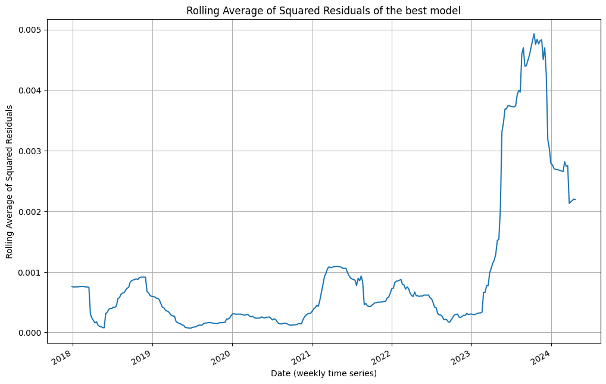

```python
plot_rolling_average_of_squared_residuals(model_results=fridays_models['AR(2) with Separate Weekly and Monthly Zero Interactions'])
```

# *Robustness work for P11*

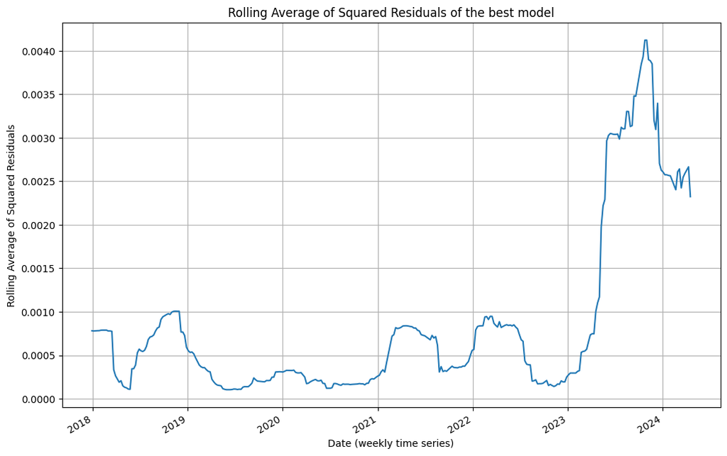

```python
# Thursdays
plot_rolling_average_of_squared_residuals(model_results=thursdays_models['AR(2) with Separate Weekly and Monthly Zero Interactions'])
```

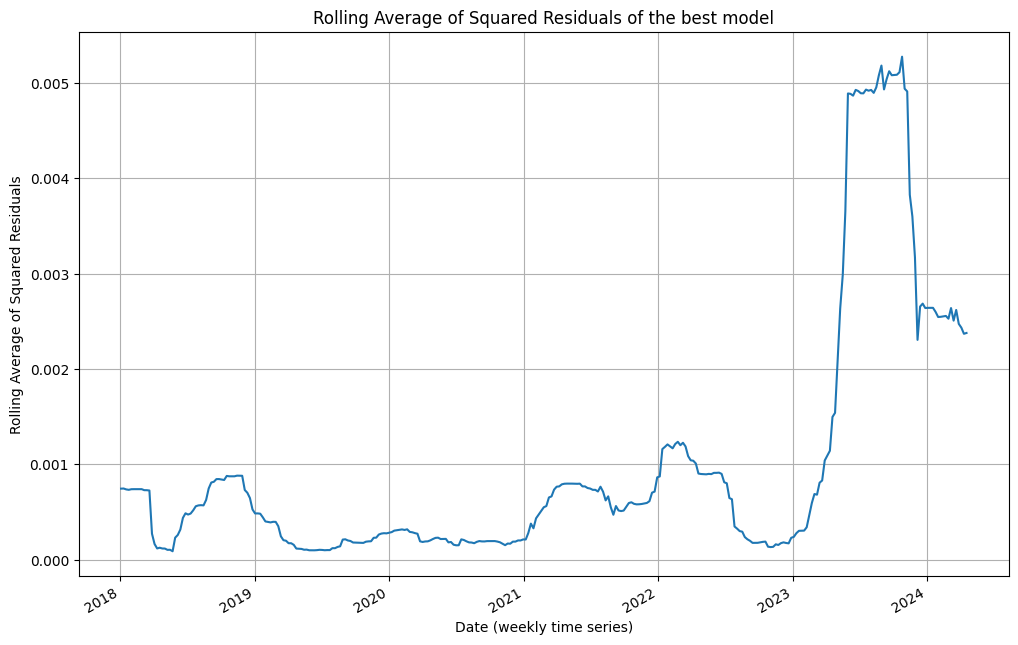

```python
# Wednesdays
plot_rolling_average_of_squared_residuals(model_results=wednesdays_models['AR(2) with Separate Weekly and Monthly Zero Interactions'])
```

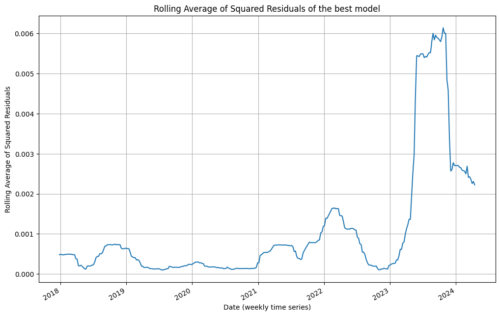

```python
# Tuesdays
plot_rolling_average_of_squared_residuals(model_results=tuesdays_models['AR(2) with Separate Weekly and Monthly Zero Interactions'])
```

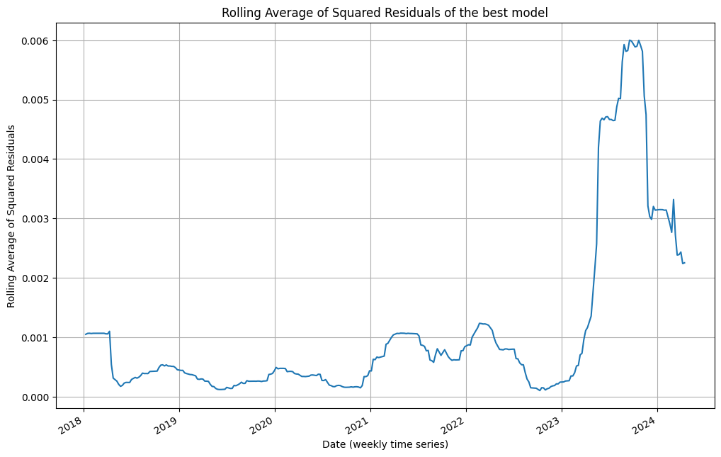

```python
# Mondays
plot_rolling_average_of_squared_residuals(model_results=mondays_models['AR(2) with Separate Weekly and Monthly Zero Interactions'])
```

# P12: Perform Out-of-Sample Forecasting and Compute RMSE (Use Fridays as an example)

```python
def prepare_input_data(df):
    """
    Prepares input data for out-of-sample predictions by creating necessary lagged
    variables and interactions based on the specified models. The function safely
    operates on a copy of the input DataFrame to avoid modifying the original data.

    Parameters:
    - df: Original DataFrame containing the columns ['Log_Return',
        'Zero_Fraction_5', 'Zero_Fraction_22'].

    Returns:
    - input_data: A new DataFrame with original and derived columns
            necessary for making predictions with all ten models.
    """
    data = df.copy()

    input_data = pd.DataFrame(index=data.index)
    input_data['Log_Return'] = data['Log_Return']
    input_data['Zero_Fraction_5'] = data['Zero_Fraction_5']
    input_data['Zero_Fraction_22'] = data['Zero_Fraction_22']

    # Create lagged features for Log_Return
    input_data['Log_Return_Lag1'] = input_data['Log_Return'].shift(1)
    input_data['Log_Return_Lag2'] = input_data['Log_Return'].shift(2)
    input_data['Z5_Lag1'] = input_data['Zero_Fraction_5'].shift(1)
    input_data['Z22_Lag1'] = input_data['Zero_Fraction_22'].shift(1)

    # Create interactions for lagged Log_Return with Zero_Fractions
    input_data['Log_Return_Lag1_Zero5'] = input_data['Log_Return_Lag1'] * input_data['Z5_Lag1']
    input_data['Log_Return_Lag1_Zero22'] = input_data['Log_Return_Lag1'] * input_data['Z22_Lag1']
    input_data['Log_Return_Lag2_Zero5'] = input_data['Log_Return_Lag2']  * input_data['Z5_Lag1']
    input_data['Log_Return_Lag2_Zero22'] = input_data['Log_Return_Lag2']  * input_data['Z22_Lag1']

    input_data.dropna(inplace=True)

    # Add constant term for regression
    input_data = sm.add_constant(input_data)

    return input_data
```

```python
def calculate_rmse(errors):
    """
    Calculate the root mean squared error for a list of errors.
    """
    mse = np.mean([e**2 for e in errors])
    return np.sqrt(mse)
```

```python
def forecast_and_compute_RMSE(df, lags, df_name):
    """
    Performs out-of-sample forecasting using a list of predefined
    models on an expanding window basis. Starting with the first
    52 observations, this function forecasts the 53rd observation
    and continues expanding the sample one observation at a time,
    re-estimating models and forecasting the next observation.
    The forecast errors are calculated for each model and used to
    compute the Root Mean Squared Error (RMSE) for each model's
    predictions. The results are then ranked by RMSE and saved to
    a csv file.

    Parameters:
    - df: A DataFrame containing the time series data, specifically
        a column 'Log_Return' which is used for the forecasting.
    - lags: Maximum number of lags to use for HAC standard errors.
    - df_name: A string that specifies the name of the DataFrame,
          used to name the output CSV file.

    Returns:
    - rmse_df: a DataFrame containing the model names and their
           corresponding RMSE, sorted by RMSE.

    Outputs:
    - Prints a sorted table of the RMSE results for each model.
    - Saves a CSV file named '{df_name}_forecast_rmse_results.csv'
      containing the RMSE results for each model based on input
      dataframe.
    """
    data = df.copy()
    perpared_data = prepare_input_data(data)
    forecast_errors = {name: [] for name, _ in models}

    # Start forecasting from the 53rd observation, using the first 52 observations initially
    for i in range(52, len(perpared_data)):
        current_sample = perpared_data[['Log_Return', 'Zero_Fraction_5',	'Zero_Fraction_22']].iloc[:i]

        for name, model_func in models:

            if name == 'Model with Only Constant':  # Special case for constant model
                forecast = current_sample['Log_Return'].mean()
            else:
                features = model_features[name]
                model = model_func(current_sample, lags)
                input_data = perpared_data.iloc[i][features]
                forecast = model.predict(input_data)

            # Actual return for the next time point (i)
            actual_return = perpared_data['Log_Return'].iloc[i]
            forecast_error = actual_return - forecast
            forecast_errors[name].append(forecast_error)

    # Compute RMSE for each model
    rmses = {name: calculate_rmse(errors) for name, errors in forecast_errors.items()}
    rmse_df = pd.DataFrame(list(rmses.items()), columns=['Model', 'RMSE'])

    # Sort by RMSE
    rmse_df.sort_values(by='RMSE', inplace=True)

    # Print the RMSE table
    print(tabulate(rmse_df, headers='keys', tablefmt='pretty', showindex=False))

    # Save the RMSE results to CSV
    # files.download is just for google colab, if u use other enviroments, plz change
    csv_filename = f'{df_name}_forecast_rmse_results.csv'
    rmse_df.to_csv(csv_filename, index=True, header=True)
    files.download(csv_filename)

    return rmse_df
```

```python
fridays_rmse = forecast_and_compute_RMSE(df=Fridays, lags=4, df_name='Fridays')
```

```
+----------------------------------------------------------+----------------------+
|                          Model                           |         RMSE         |
+----------------------------------------------------------+----------------------+
|                          AR(2)                           | 0.03319323376216553  |
|                          AR(1)                           | 0.03347683497575105  |
|            AR(2) with Weekly Zero Interaction            | 0.03405335419043286  |
|            AR(1) with Weekly Zero Interaction            | 0.034065014359989744 |
|           AR(1) with Monthly Zero Interaction            | 0.03411353705615823  |
|           AR(2) with Monthly Zero Interaction            | 0.03424400124657069  |
| AR(2) with Separate Weekly and Monthly Zero Interactions | 0.03428830145726344  |
|                 Model with Only Constant                 | 0.047601851591042715 |
|                  Model with Weekly Zero                  | 0.048056696113039886 |
|                 Model with Monthly Zero                  | 0.04812928878062246  |
+----------------------------------------------------------+----------------------+
```

The model **AR(2)** wins in $RMSE$ criteria with lowest RMSE. This mix model has acceptably low RMSE (very close to the winner), which signifies high accuracy in predictive performance. It means that the mix model's predictions are, on average, close to the actual observed weekly log return.

# *Robustness work for P12*

```python
# Thursdays
thursdays_rmse = forecast_and_compute_RMSE(df=Thursdays, lags=2, df_name='Thursdays')
```

```
+----------------------------------------------------------+----------------------+
|                          Model                           |         RMSE         |
+----------------------------------------------------------+----------------------+
|                          AR(1)                           | 0.031228836428829586 |
|                          AR(2)                           | 0.03131017690997134  |
|            AR(2) with Weekly Zero Interaction            | 0.03131377832533065  |
|            AR(1) with Weekly Zero Interaction            | 0.031661200730862635 |
|           AR(1) with Monthly Zero Interaction            | 0.03195213191312714  |
|           AR(2) with Monthly Zero Interaction            | 0.03205756605217784  |
| AR(2) with Separate Weekly and Monthly Zero Interactions | 0.03208375760971013  |
|                 Model with Only Constant                 | 0.04684102151231067  |
|                  Model with Weekly Zero                  | 0.04728509441637568  |
|                 Model with Monthly Zero                  | 0.04735288128098435  |
+----------------------------------------------------------+----------------------+
```

```python
# Wednesdays
wednesdays_rmse = forecast_and_compute_RMSE(df=Wednesdays, lags=2, df_name='Wednesdays')
```

```
+----------------------------------------------------------+----------------------+
|                          Model                           |         RMSE         |
+----------------------------------------------------------+----------------------+
|                          AR(1)                           |  0.0344754974330957  |
|                          AR(2)                           | 0.034532832194297196 |
|            AR(1) with Weekly Zero Interaction            | 0.03495969979970849  |
|           AR(1) with Monthly Zero Interaction            | 0.03531270390755053  |
|            AR(2) with Weekly Zero Interaction            | 0.035383770340930286 |
|           AR(2) with Monthly Zero Interaction            | 0.03584111892682286  |
| AR(2) with Separate Weekly and Monthly Zero Interactions | 0.03587648812686814  |
|                 Model with Only Constant                 | 0.047647999920785465 |
|                 Model with Monthly Zero                  | 0.048032922633657125 |
|                  Model with Weekly Zero                  | 0.04804314037456729  |
+----------------------------------------------------------+----------------------+
```

```python
# Tuesdays
tuesdays_rmse = forecast_and_compute_RMSE(df=Tuesdays, lags=2, df_name='Tuesdays')
```

```
+----------------------------------------------------------+----------------------+
|                          Model                           |         RMSE         |
+----------------------------------------------------------+----------------------+
|                          AR(2)                           |  0.0363193179205231  |
|                          AR(1)                           | 0.03668898286049331  |
|            AR(1) with Weekly Zero Interaction            | 0.03706180633461377  |
|            AR(2) with Weekly Zero Interaction            | 0.03721136921820577  |
| AR(2) with Separate Weekly and Monthly Zero Interactions | 0.037419351322153495 |
|           AR(1) with Monthly Zero Interaction            | 0.03750723478198474  |
|           AR(2) with Monthly Zero Interaction            | 0.03768697952584409  |
|                 Model with Only Constant                 | 0.048320938820529416 |
|                  Model with Weekly Zero                  | 0.04879089668801973  |
|                 Model with Monthly Zero                  | 0.04882150180841967  |
+----------------------------------------------------------+----------------------+
```

```python
# Mondays
mondays_rmse = forecast_and_compute_RMSE(df=Mondays, lags=2, df_name='Mondays')
```

```
+----------------------------------------------------------+----------------------+
|                          Model                           |         RMSE         |
+----------------------------------------------------------+----------------------+
|                          AR(2)                           | 0.03668184362733399  |
|                          AR(1)                           | 0.037050763630292645 |
|            AR(1) with Weekly Zero Interaction            | 0.03739738770736273  |
|            AR(2) with Weekly Zero Interaction            | 0.03754236275505407  |
| AR(2) with Separate Weekly and Monthly Zero Interactions | 0.03761768044852644  |
|           AR(2) with Monthly Zero Interaction            | 0.03776959641579725  |
|           AR(1) with Monthly Zero Interaction            |  0.0379527480142736  |
|                 Model with Only Constant                 | 0.04851899399219849  |
|                 Model with Monthly Zero                  | 0.04911067061442834  |
|                  Model with Weekly Zero                  | 0.049170200104615945 |
+----------------------------------------------------------+----------------------+
```

The winners in $RMSE$ criteria across different dataframes are **AR(2)** or **AR(1)** models, but the mix model also has accpetably low RMSE, which is very close to these two winners.

# Source of the weirdly lowh Ljung Box p-values for the Fridays series

```python
model_test = fridays_models['AR(2) with Separate Weekly and Monthly Zero Interactions']
residuals = model_test.resid
ljung_box_results = acorr_ljungbox(residuals, lags=[3], return_df=True)

print("Ljung-Box test results for the first three lags:")
print(ljung_box_results)
```

```
Ljung-Box test results for the first three lags:
     lb_stat  lb_pvalue
3  20.599384   0.000127
```

large 'lb_stat' and low 'lb_pvalue'

### Compute the autocorrelations of the residuals at the first three lags

```python
# Fridays
model_test = fridays_models['AR(2) with Separate Weekly and Monthly Zero Interactions']
residuals = model_test.resid
autocorrs = acf(residuals, nlags=3, fft=True)
print("Autocorrelations at the first three lags:", autocorrs[1:])
print("Fridays' third autocorrelation:", autocorrs[3])
```

```
Autocorrelations at the first three lags: [-0.03643096 -0.08550913  0.2336051 ]
Fridays' third autocorrelation: 0.23360509797963613
```

```python
# Mondays
model_test = mondays_models['AR(2) with Separate Weekly and Monthly Zero Interactions']
residuals = model_test.resid
autocorrs = acf(residuals, nlags=3, fft=True)
print("Autocorrelations at the first three lags:", autocorrs[1:])
print("Mondays' third autocorrelation:", autocorrs[3])
```

```
Autocorrelations at the first three lags: [-0.02202399 -0.03511626  0.08901346]
Mondays' third autocorrelation: 0.08901345731509394
```

```python
# Tuesdays
model_test = tuesdays_models['AR(2) with Separate Weekly and Monthly Zero Interactions']
residuals = model_test.resid
autocorrs = acf(residuals, nlags=3, fft=True)
print("Autocorrelations at the first three lags:", autocorrs[1:])
print("Tuesdays' third autocorrelation:", autocorrs[3])
```

```
Autocorrelations at the first three lags: [ 0.00817138  0.0021737  -0.01097647]
Tuesdays' third autocorrelation: -0.010976472633772105
```

```python
# Wednesdays
model_test = wednesdays_models['AR(2) with Separate Weekly and Monthly Zero Interactions']
residuals = model_test.resid
autocorrs = acf(residuals, nlags=3, fft=True)
print("Autocorrelations at the first three lags:", autocorrs[1:])
print("Wednesdays' third autocorrelation:", autocorrs[3])
```

```
Autocorrelations at the first three lags: [-0.01120693 -0.02472329 -0.02155822]
Wednesdays' third autocorrelation: -0.02155821724733596
```

```python
# Thursdays
model_test = thursdays_models['AR(2) with Separate Weekly and Monthly Zero Interactions']
residuals = model_test.resid
autocorrs = acf(residuals, nlags=3, fft=True)
print("Autocorrelations at the first three lags:", autocorrs[1:])
print("Thursdays' third autocorrelation:", autocorrs[3])
```

```
Autocorrelations at the first three lags: [-0.01760913 -0.04974084  0.02741009]
Thursdays' third autocorrelation: 0.027410086612236765
```

Comparing Fridays and other four data, it is obivous that the reason for the Ljung-Box test rejecting the null hypothesis of no autocorrelation for models based on Fridays is the unusually higher third autocorrelation ($0.234$) than other four data ($0.089, -0.011, -0.022, 0.027$), where first two autocorrelations have no significant difference between these five data.

# P13: Forecast Graph

```python
def generate_forecast_plot(df, lags, df_name):
   """
   Generates a plot showing the actual observed returns and the out-of-sample
   forecasted returns for the given DataFrame using the AR(2) model with
   separate interactions for zero fractions

   Parameters:
   - df: The input DataFrame containing the data. It must
       include the following columns: 'Log_Return',
       'Zero_Fraction_5', and 'Zero_Fraction_22'.
   - lags: Maximum number of lags to use for HAC standard errors.
   - df_name: A string that specifies the name of the DataFrame,
         used to name the plot titles.

   Returns:
   - forecasted_series: A series of out-of-sample forecast results
   - Plot Actual vs Forecasted Weekly Log Return
   """
   data = df.copy()
   perpared_data = prepare_input_data(data)
   forecasted_returns = []

   for i in range(52, len(perpared_data)):
       train_data = perpared_data[['Log_Return', 'Zero_Fraction_5',	'Zero_Fraction_22']].iloc[:i]
       features = model_features['AR(2) with Separate Weekly and Monthly Zero Interactions']
       model = estimate_model_ar2_z5_z22_separate_interaction(train_data, lags)
       input_data = perpared_data.iloc[i][features]
       forecast = model.predict(input_data)
       forecasted_returns.append(forecast[0])

   # Adjust the index for forecasted returns
   forecasted_index = perpared_data.index[52:]
   forecasted_series = pd.Series(forecasted_returns, index=forecasted_index)

   marker_positions = forecasted_index[::12]

   # Plot the actual vs forecasted returns
   plt.figure(figsize=(20, 10))
   plt.plot(perpared_data.index, perpared_data['Log_Return'], label='Actual Lithium Return', color='blue', linewidth=1.3)
   plt.plot(marker_positions, perpared_data.loc[marker_positions, 'Log_Return'], 'bo', markersize=5)
   plt.plot(forecasted_series.index, forecasted_series, label='Out-of-sample Forecasted Return', color='red', linewidth=1.5)
   plt.plot(marker_positions, forecasted_series.loc[marker_positions], 'r^', markersize=7)
   plt.axhline(0, color='k', linestyle='--', linewidth=0.8)
   plt.xlabel('Weekly Date', fontsize=12)
   plt.ylabel('Weekly Log Returns', fontsize=12)
   plt.title(f'Actual vs Forecasted Weekly Log Return for {df_name}', fontsize=16)
   plt.legend(loc='upper left', fontsize=12)
   plt.grid(True, linestyle='--', alpha=0.7)
   plt.show()

   return forecasted_series
```

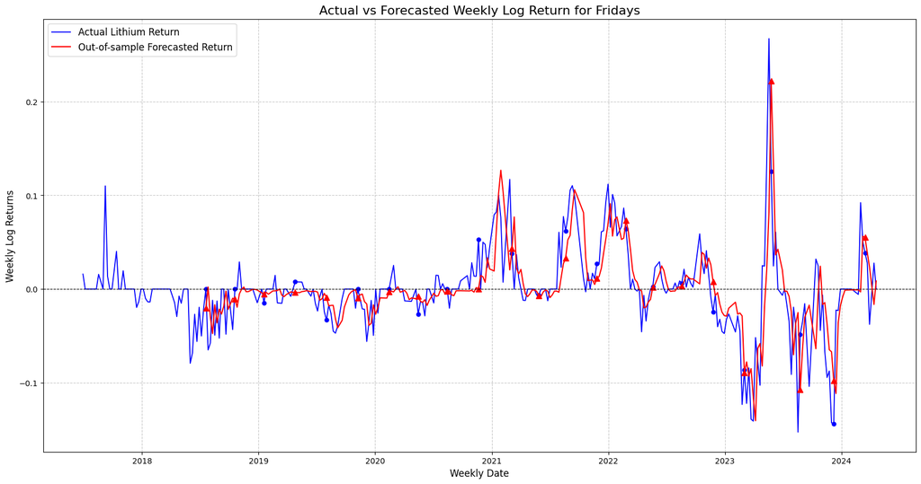

```python
fridays_forecast = generate_forecast_plot(Fridays, lags=4, df_name='Fridays')
```

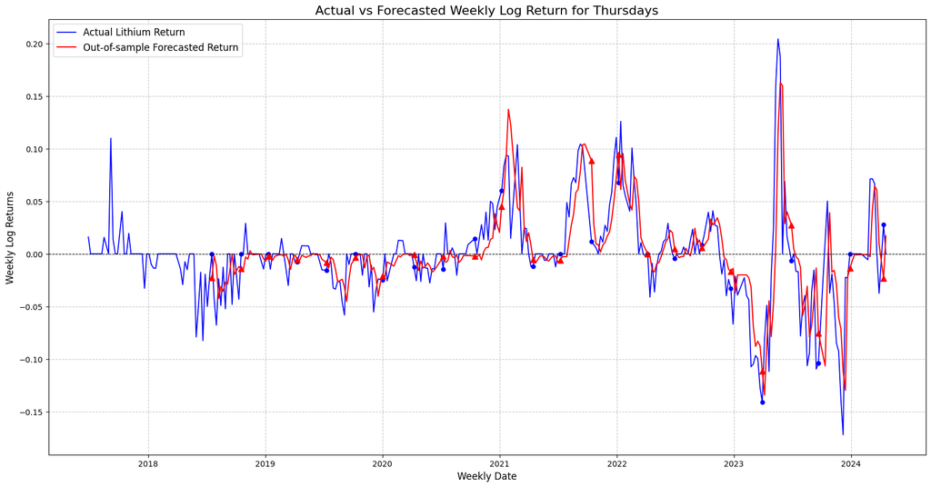

```python
thursdays_forecast = generate_forecast_plot(Thursdays, lags=2, df_name='Thursdays')
```

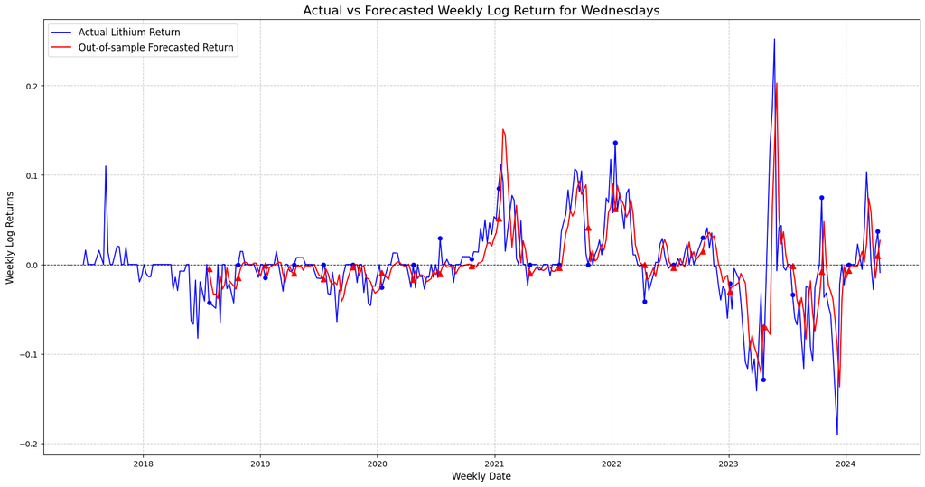

```python
wednesdays_forecast = generate_forecast_plot(Wednesdays, lags=2, df_name='Wednesdays')
```

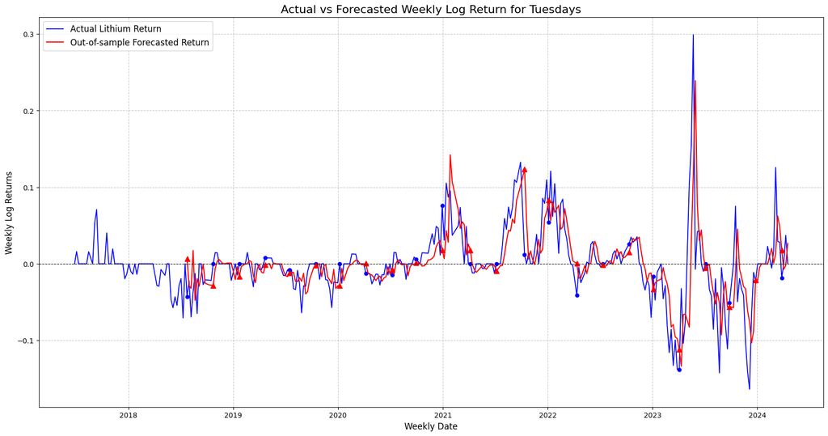

```python
tuesdays_forecast = generate_forecast_plot(Tuesdays, lags=2, df_name='Tuesdays')
```

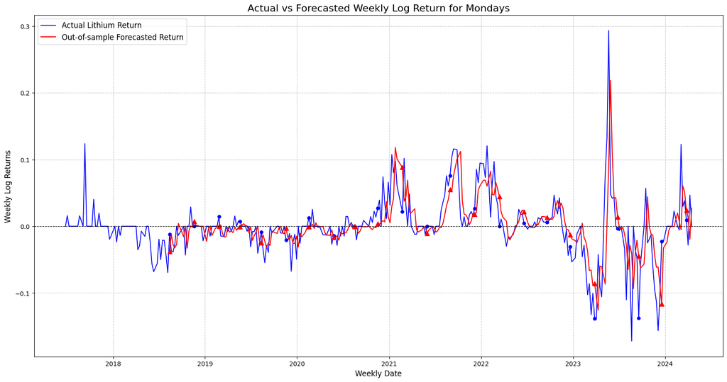

```python
mondays_forecast = generate_forecast_plot(Mondays, lags=2, df_name='Mondays')
```

# **New** P14: Unbiasedness test of the forecasts

```python
def ex_post_regression(df, forecasted_return, lags):
    """
    Perform an ex-post regression to test the unbiasedness of forecasts.

    Parameters:
    - df (Dataframe): A dataframe contains actual returns r(t).
    - forecasted_return (pd.Series): A series of forecasted returns r^(t).
    - lags: Maximum number of lags to use for HAC standard errors.

    Returns:
    - Print a formatted table containing the coefficient, t-statistic, and p-value for the forecasted returns coefficient.
    """
    data = df.copy()
    prepared_data = prepare_input_data(data)
    # Let the index of actual return series match that of forecasted return series
    actual_return = prepared_data['Log_Return'].iloc[52:]
    X = sm.add_constant(forecasted_return)
    model = sm.OLS(actual_return, X).fit(cov_type='HAC', cov_kwds={'maxlags': lags})
    print(model.summary())
    b_coefficient = model.params[0]
    t_statistic = model.tvalues[0]
    p_value = model.pvalues[0]
    results = {
        'b coefficient': b_coefficient,
        't-statistic': t_statistic,
        'p-value': p_value
    }

    table = tabulate(results.items(), headers=['Metric', 'Value'], tablefmt='pretty', showindex=False)
    print(table)
```

```python
ex_post_regression(df=Fridays, forecasted_return=fridays_forecast, lags=4)
```

```
                            OLS Regression Results
==============================================================================
Dep. Variable:             Log_Return   R-squared:                       0.492
Model:                            OLS   Adj. R-squared:                  0.490
Method:                 Least Squares   F-statistic:                     122.2
Date:                Mon, 03 Jun 2024   Prob (F-statistic):           1.21e-23
Time:                        18:51:50   Log-Likelihood:                 529.42
No. Observations:                 269   AIC:                            -1055.
Df Residuals:                     267   BIC:                            -1048.
Df Model:                           1
Covariance Type:                  HAC
==============================================================================
                 coef    std err          z      P>|z|      [0.025      0.975]
------------------------------------------------------------------------------
const      -2.977e-05      0.002     -0.012      0.990      -0.005       0.005
0              0.8535      0.077     11.056      0.000       0.702       1.005
==============================================================================
Omnibus:                       54.471   Durbin-Watson:                   1.791
Prob(Omnibus):                  0.000   Jarque-Bera (JB):              372.352
Skew:                           0.570   Prob(JB):                     1.40e-81
Kurtosis:                       8.650   Cond. No.                         25.6
==============================================================================

Notes:
[1] Standard Errors are heteroscedasticity and autocorrelation robust (HAC) using 4 lags and without small sample correction
+---------------+------------------------+
|    Metric     |         Value          |
+---------------+------------------------+
| b coefficient |   0.8535421296638047   |
|  t-statistic  |   11.055664492292182   |
|    p-value    | 2.0580710313524815e-28 |
+---------------+------------------------+
```

```python
ex_post_regression(df=Thursdays, forecasted_return=thursdays_forecast, lags=2)
```

```
                            OLS Regression Results
==============================================================================
Dep. Variable:             Log_Return   R-squared:                       0.540
Model:                            OLS   Adj. R-squared:                  0.538
Method:                 Least Squares   F-statistic:                     115.7
Date:                Mon, 03 Jun 2024   Prob (F-statistic):           9.28e-23
Time:                        18:52:59   Log-Likelihood:                 565.19
No. Observations:                 278   AIC:                            -1126.
Df Residuals:                     276   BIC:                            -1119.
Df Model:                           1
Covariance Type:                  HAC
==============================================================================
                 coef    std err          z      P>|z|      [0.025      0.975]
------------------------------------------------------------------------------
const         -0.0005      0.002     -0.219      0.827      -0.005       0.004
0              0.8721      0.081     10.754      0.000       0.713       1.031
==============================================================================
Omnibus:                       32.854   Durbin-Watson:                   1.638
Prob(Omnibus):                  0.000   Jarque-Bera (JB):              194.346
Skew:                           0.064   Prob(JB):                     6.29e-43
Kurtosis:                       7.094   Cond. No.                         25.4
==============================================================================

Notes:
[1] Standard Errors are heteroscedasticity and autocorrelation robust (HAC) using 2 lags and without small sample correction
+---------------+-----------------------+
|    Metric     |         Value         |
+---------------+-----------------------+
| b coefficient |  0.8720799141555767   |
|  t-statistic  |  10.754105458742975   |
|    p-value    | 5.668129349478561e-27 |
+---------------+-----------------------+
```

Similar results as Friday to Friday

```python
ex_post_regression(df=Wednesdays, forecasted_return=wednesdays_forecast, lags=2)
```

```
                            OLS Regression Results
==============================================================================
Dep. Variable:             Log_Return   R-squared:                       0.449
Model:                            OLS   Adj. R-squared:                  0.447
Method:                 Least Squares   F-statistic:                     74.51
Date:                Mon, 03 Jun 2024   Prob (F-statistic):           4.88e-16
Time:                        18:53:02   Log-Likelihood:                 535.45
No. Observations:                 278   AIC:                            -1067.
Df Residuals:                     276   BIC:                            -1060.
Df Model:                           1
Covariance Type:                  HAC
==============================================================================
                 coef    std err          z      P>|z|      [0.025      0.975]
------------------------------------------------------------------------------
const         -0.0002      0.002     -0.094      0.925      -0.005       0.004
0              0.8279      0.096      8.632      0.000       0.640       1.016
==============================================================================
Omnibus:                       51.396   Durbin-Watson:                   1.655
Prob(Omnibus):                  0.000   Jarque-Bera (JB):              529.231
Skew:                           0.282   Prob(JB):                    1.20e-115
Kurtosis:                       9.736   Cond. No.                         26.0
==============================================================================

Notes:
[1] Standard Errors are heteroscedasticity and autocorrelation robust (HAC) using 2 lags and without small sample correction
+---------------+------------------------+
|    Metric     |         Value          |
+---------------+------------------------+
| b coefficient |   0.8279232315944781   |
|  t-statistic  |   8.631861350275683    |
|    p-value    | 6.0361526891087934e-18 |
+---------------+------------------------+
```

Similar results as Friday to Friday

```python
ex_post_regression(df=Tuesdays, forecasted_return=tuesdays_forecast, lags=2)
```

```
                            OLS Regression Results
==============================================================================
Dep. Variable:             Log_Return   R-squared:                       0.421
Model:                            OLS   Adj. R-squared:                  0.419
Method:                 Least Squares   F-statistic:                     55.40
Date:                Mon, 03 Jun 2024   Prob (F-statistic):           1.23e-12
Time:                        18:53:26   Log-Likelihood:                 528.36
No. Observations:                 280   AIC:                            -1053.
Df Residuals:                     278   BIC:                            -1045.
Df Model:                           1
Covariance Type:                  HAC
==============================================================================
                 coef    std err          z      P>|z|      [0.025      0.975]
------------------------------------------------------------------------------
const         -0.0002      0.002     -0.092      0.926      -0.005       0.004
0              0.8071      0.108      7.443      0.000       0.595       1.020
==============================================================================
Omnibus:                       63.265   Durbin-Watson:                   1.719
Prob(Omnibus):                  0.000   Jarque-Bera (JB):              802.598
Skew:                           0.436   Prob(JB):                    5.22e-175
Kurtosis:                      11.248   Cond. No.                         25.8
==============================================================================

Notes:
[1] Standard Errors are heteroscedasticity and autocorrelation robust (HAC) using 2 lags and without small sample correction
+---------------+----------------------+
|    Metric     |        Value         |
+---------------+----------------------+
| b coefficient |  0.8070958437789344  |
|  t-statistic  |  7.4432265528796675  |
|    p-value    | 9.82553673773781e-14 |
+---------------+----------------------+
```

Similar results as Friday to Friday

```python
ex_post_regression(df=Mondays, forecasted_return=mondays_forecast, lags=2)
```

```
                            OLS Regression Results
==============================================================================
Dep. Variable:             Log_Return   R-squared:                       0.410
Model:                            OLS   Adj. R-squared:                  0.408
Method:                 Least Squares   F-statistic:                     73.91
Date:                Mon, 03 Jun 2024   Prob (F-statistic):           7.13e-16
Time:                        18:53:29   Log-Likelihood:                 502.45
No. Observations:                 268   AIC:                            -1001.
Df Residuals:                     266   BIC:                            -993.7
Df Model:                           1
Covariance Type:                  HAC
==============================================================================
                 coef    std err          z      P>|z|      [0.025      0.975]
------------------------------------------------------------------------------
const         -0.0002      0.002     -0.083      0.934      -0.005       0.005
0              0.8348      0.097      8.597      0.000       0.644       1.025
==============================================================================
Omnibus:                       66.174   Durbin-Watson:                   1.728
Prob(Omnibus):                  0.000   Jarque-Bera (JB):              481.188
Skew:                           0.750   Prob(JB):                    3.25e-105
Kurtosis:                       9.391   Cond. No.                         27.0
==============================================================================

Notes:
[1] Standard Errors are heteroscedasticity and autocorrelation robust (HAC) using 2 lags and without small sample correction
+---------------+-----------------------+
|    Metric     |         Value         |
+---------------+-----------------------+
| b coefficient |  0.8347515603741322   |
|  t-statistic  |   8.596850736326246   |
|    p-value    | 8.193344205106168e-18 |
+---------------+-----------------------+
```

Similar results as Friday to Friday

# **New** P15: Three MSE Statistics

```python
# Define the critical values from McCracken's Table 4 for pi = 2.0
mccracken_critical_values = {
    1: {0.01: 3.951, 0.05: 1.518, 0.10: 0.616},
    2: {0.01: 4.250, 0.05: 1.706, 0.10: 0.506},
    3: {0.01: 4.184, 0.05: 1.612, 0.10: 0.127},
    4: {0.01: 4.096, 0.05: 1.029, 0.10: -0.456},
    5: {0.01: 3.783, 0.05: 0.459, 0.10: -1.072},
    6: {0.01: 3.321, 0.05: -0.109, 0.10: -1.664},
}
```

```python
def calculate_statistics(RMSE_df, forecast_series, df_name):
    """
    Calculate the R², Adjusted R², and McCracken statistics for the given RMSE values of different models.

    Parameters:
    - RMSE_df (pd.DataFrame): A DataFrame containing model names and their corresponding RMSE values.
    - forecast_series (pd.Series): A series containing the forecasted return values.
    - df_name: A string that specifies the name of the DataFrame, used to name the output CSV file.

    Returns:
    - result_df (pd.DataFrame): A DataFrame containing the R², Adjusted R², and McCracken statistics for each model.
    - Print result_df
    - Store the result_df to a CSV file
    """
    df = RMSE_df.copy()

    df['MSE'] = df['RMSE'] ** 2
    mse_mean = df.loc[df['Model'] == 'Model with Only Constant', 'MSE'].values[0]

    # Calculate R² values
    df['R^2'] = 1 - (df['MSE'] / mse_mean)

    # Calculate Adjusted R² values
    T = len(forecast_series)
    df['k'] = df['Model'].apply(lambda x: len(model_features.get(x, ['const'])))
    df['Adj R^2'] = 1 - (1 - df['R^2']) * ((T - df['k']) / (T - 1))

    # Calculate McCracken statistics
    df['McCracken Stat'] = T * (mse_mean - df['MSE']) / df['MSE']

    df['k2'] = df['k'] - 1

    # Determine significance using critical values
    df['Significance 1%'] = df.apply(lambda row: row['McCracken Stat'] > mccracken_critical_values[row['k2']][0.01] if row['k2'] in mccracken_critical_values else False, axis=1)
    df['Significance 5%'] = df.apply(lambda row: row['McCracken Stat'] > mccracken_critical_values[row['k2']][0.05] if row['k2'] in mccracken_critical_values else False, axis=1)
    df['Significance 10%'] = df.apply(lambda row: row['McCracken Stat'] > mccracken_critical_values[row['k2']][0.10] if row['k2'] in mccracken_critical_values else False, axis=1)

    df['Significance 1%'] = df['Significance 1%'].apply(lambda x: 'significant' if x else 'not significant')
    df['Significance 5%'] = df['Significance 5%'].apply(lambda x: 'significant' if x else 'not significant')
    df['Significance 10%'] = df['Significance 10%'].apply(lambda x: 'significant' if x else 'not significant')

    # Select only the required columns
    result_df = df[['Model', 'R^2', 'Adj R^2', 'McCracken Stat', 'Significance 1%', 'Significance 5%', 'Significance 10%']]

    print(tabulate(result_df, headers='keys', tablefmt='pretty', showindex=False))

    csv_filename = f'{df_name}_mse_statistics.csv'
    result_df.to_csv(csv_filename, index=True, header=True)
    files.download(csv_filename)

    return result_df
```

```python
fridays_mse_statistics = calculate_statistics(fridays_rmse, fridays_forecast, df_name='Fridays')
```

```
+----------------------------------------------------------+-----------------------+-----------------------+---------------------+-----------------+-----------------+------------------+
|                          Model                           |          R^2          |        Adj R^2        |   McCracken Stat    | Significance 1% | Significance 5% | Significance 10% |
+----------------------------------------------------------+-----------------------+-----------------------+---------------------+-----------------+-----------------+------------------+
|                          AR(2)                           |  0.5137591556318142   |  0.5173878186494872   | 284.22378429466283  |   significant   |   significant   |   significant    |
|                          AR(1)                           |  0.5054148290003098   |  0.5072602960562788   |  274.8901442521585  |   significant   |   significant   |   significant    |
|            AR(2) with Weekly Zero Interaction            |  0.48823321093949523  |  0.4977810987951017   |  256.6300442899527  |   significant   |   significant   |   significant    |
|            AR(1) with Weekly Zero Interaction            |  0.4878826839913033   |  0.49361534051378875  | 256.27026833717116  |   significant   |   significant   |   significant    |
|           AR(1) with Monthly Zero Interaction            |  0.4864227103935349   |   0.492171709904055   | 254.77705448409642  |   significant   |   significant   |   significant    |
|           AR(2) with Monthly Zero Interaction            |  0.4824869373569941   |  0.49214203180928895  |  250.7936427462958  |   significant   |   significant   |   significant    |
| AR(2) with Separate Weekly and Monthly Zero Interactions |  0.4811470958607106   |  0.49276320565487375  |  249.4513719668517  |   significant   |   significant   |   significant    |
|                 Model with Only Constant                 |          0.0          |          0.0          |         0.0         | not significant | not significant | not significant  |
|                  Model with Weekly Zero                  | -0.019201672565752448 | -0.015398681250208712 |  -5.06793705232482  | not significant | not significant | not significant  |
|                 Model with Monthly Zero                  | -0.02228313487554745  | -0.018468645566310338 | -5.8635059867753725 | not significant | not significant | not significant  |
+----------------------------------------------------------+-----------------------+-----------------------+---------------------+-----------------+-----------------+------------------+
```

```python
thursdays_mse_statistics = calculate_statistics(thursdays_rmse, thursdays_forecast, df_name='Thursdays')
```

```
+----------------------------------------------------------+----------------------+-----------------------+--------------------+-----------------+-----------------+------------------+
|                          Model                           |         R^2          |        Adj R^2        |   McCracken Stat   | Significance 1% | Significance 5% | Significance 10% |
+----------------------------------------------------------+----------------------+-----------------------+--------------------+-----------------+-----------------+------------------+
|                          AR(1)                           |  0.555513177047838   |  0.5571178226180624   | 347.4403632341645  |   significant   |   significant   |   significant    |
|                          AR(2)                           |  0.5531946880093286  |  0.5564207191428352   | 344.1949304080883  |   significant   |   significant   |   significant    |
|            AR(2) with Weekly Zero Interaction            |  0.553091895612974   |  0.5611588289051586   | 344.0518206562881  |   significant   |   significant   |   significant    |
|            AR(1) with Weekly Zero Interaction            |  0.5431201052564556  |  0.5480682629612593   | 330.4750132330659  |   significant   |   significant   |   significant    |
|           AR(1) with Monthly Zero Interaction            |  0.5346850932516728  |  0.5397246048771059   | 319.4448614653143  |   significant   |   significant   |   significant    |
|           AR(2) with Monthly Zero Interaction            |  0.5316091783312928  |  0.5400638863036522   | 315.52145076111117 |   significant   |   significant   |   significant    |
| AR(2) with Separate Weekly and Monthly Zero Interactions |  0.5308434996977309  |  0.5410057343613179   | 314.55280449250864 |   significant   |   significant   |   significant    |
|                 Model with Only Constant                 |         0.0          |          0.0          |        0.0         | not significant | not significant | not significant  |
|                  Model with Weekly Zero                  | -0.01905073331557028 | -0.015371849801795623 | -5.197095383560765 | not significant | not significant | not significant  |
|                 Model with Monthly Zero                  | -0.02197460475834956 | -0.018285165752001564 | -5.977585053853333 | not significant | not significant | not significant  |
+----------------------------------------------------------+----------------------+-----------------------+--------------------+-----------------+-----------------+------------------+
```

```python
wednesdays_mse_statistics = calculate_statistics(wednesdays_rmse, wednesdays_forecast, df_name='Wednesdays')
```

```
+----------------------------------------------------------+-----------------------+-----------------------+---------------------+-----------------+-----------------+------------------+
|                          Model                           |          R^2          |        Adj R^2        |   McCracken Stat    | Significance 1% | Significance 5% | Significance 10% |
+----------------------------------------------------------+-----------------------+-----------------------+---------------------+-----------------+-----------------+------------------+
|                          AR(1)                           |  0.47648186367937473  |  0.47837182085020735  | 253.02267278423517  |   significant   |   significant   |   significant    |
|                          AR(2)                           |  0.4747391334176516   |  0.47853163064929316  | 251.26082578515528  |   significant   |   significant   |   significant    |
|            AR(1) with Weekly Zero Interaction            |  0.4616731536053529   |  0.4675034082594466   | 238.41489155121633  |   significant   |   significant   |   significant    |
|           AR(1) with Monthly Zero Interaction            |  0.45074680084813157  |  0.45669539145266447  |  228.1417947665573  |   significant   |   significant   |   significant    |
|            AR(2) with Weekly Zero Interaction            |  0.44853384410589636  |  0.45848810684766717  | 226.11071836180543  |   significant   |   significant   |   significant    |
|           AR(2) with Monthly Zero Interaction            |  0.43418589681330866  |  0.4443991477733572   | 213.32744912912398  |   significant   |   significant   |   significant    |
| AR(2) with Separate Weekly and Monthly Zero Interactions |  0.43306861770772254  |  0.4453487198512376   | 212.35916635265582  |   significant   |   significant   |   significant    |
|                 Model with Only Constant                 |          0.0          |          0.0          |         0.0         | not significant | not significant | not significant  |
|                 Model with Monthly Zero                  | -0.016222192154939696 | -0.012553519981095107 | -4.437778916744636  | not significant | not significant | not significant  |
|                  Model with Weekly Zero                  | -0.016654587225026773 | -0.01298435405814935  | -4.5541281244744285 | not significant | not significant | not significant  |
+----------------------------------------------------------+-----------------------+-----------------------+---------------------+-----------------+-----------------+------------------+
```

```python
tuesdays_mse_statistics = calculate_statistics(tuesdays_rmse, tuesdays_forecast, df_name='Tuesdays')
```

```
+----------------------------------------------------------+-----------------------+----------------------+--------------------+-----------------+-----------------+------------------+
|                          Model                           |          R^2          |       Adj R^2        |   McCracken Stat   | Significance 1% | Significance 5% | Significance 10% |
+----------------------------------------------------------+-----------------------+----------------------+--------------------+-----------------+-----------------+------------------+
|                          AR(2)                           |   0.435056988582293   |  0.4391067592734593  | 215.62521235079745 |   significant   |   significant   |   significant    |
|                          AR(1)                           |  0.42349826770477994  | 0.42556458215745097  | 205.68804621841997 |   significant   |   significant   |   significant    |
|            AR(1) with Weekly Zero Interaction            |  0.4117222298251434   |  0.4180477972463784  | 195.96563085627776 |   significant   |   significant   |   significant    |
|            AR(2) with Weekly Zero Interaction            |  0.4069646608288342   |  0.417592534290683   | 192.14724234028245 |   significant   |   significant   |   significant    |
| AR(2) with Separate Weekly and Monthly Zero Interactions |  0.4003169384413602   | 0.41321334836735246  | 186.91330462503035 |   significant   |   significant   |   significant    |
|           AR(1) with Monthly Zero Interaction            |  0.39749678743025463  |  0.4039753165976713  | 184.72781249707842 |   significant   |   significant   |   significant    |
|           AR(2) with Monthly Zero Interaction            |  0.3917082359738825   |  0.4026095220675405  | 180.30542670306144 |   significant   |   significant   |   significant    |
|                 Model with Only Constant                 |          0.0          |         0.0          |        0.0         | not significant | not significant | not significant  |
|                  Model with Weekly Zero                  | -0.019546110973747144 | -0.01589182383764043 | -5.367987787646174 | not significant | not significant | not significant  |
|                 Model with Monthly Zero                  | -0.020825575794964024 | -0.01716670276344079 | -5.712201340614871 | not significant | not significant | not significant  |
+----------------------------------------------------------+-----------------------+----------------------+--------------------+-----------------+-----------------+------------------+
```

```python
mondays_mse_statistics = calculate_statistics(mondays_rmse, mondays_forecast, df_name='Mondays')
```

```
+----------------------------------------------------------+-----------------------+-----------------------+--------------------+-----------------+-----------------+------------------+
|                          Model                           |          R^2          |        Adj R^2        |   McCracken Stat   | Significance 1% | Significance 5% | Significance 10% |
+----------------------------------------------------------+-----------------------+-----------------------+--------------------+-----------------+-----------------+------------------+
|                          AR(2)                           |  0.42841774781927766  |  0.4326992628168861   | 200.87390043605484 |   significant   |   significant   |   significant    |
|                          AR(1)                           |  0.41686279385073877  |  0.4190468283306985   | 191.58309155015925 |   significant   |   significant   |   significant    |
|            AR(1) with Weekly Zero Interaction            |  0.40590081223812435  |  0.41257608401072976  | 183.10312473178917 |   significant   |   significant   |   significant    |
|            AR(2) with Weekly Zero Interaction            |  0.40128570360743265  |  0.41249758181703133  | 179.62585696513366 |   significant   |   significant   |   significant    |
| AR(2) with Separate Weekly and Monthly Zero Interactions |  0.3988810060745892   |   0.412389298072913   | 177.8351885537899  |   significant   |   significant   |   significant    |
|           AR(2) with Monthly Zero Interaction            |  0.39401606141662493  |  0.4053640752477743   | 174.2559459686519  |   significant   |   significant   |   significant    |
|           AR(1) with Monthly Zero Interaction            |  0.3881247607201256   |  0.3949997634086635   | 169.99778581564013 |   significant   |   significant   |   significant    |
|                 Model with Only Constant                 |          0.0          |          0.0          |        0.0         | not significant | not significant | not significant  |
|                 Model with Monthly Zero                  | -0.024538196082734665 | -0.020700974374559644 | -6.418732435078348 | not significant | not significant | not significant  |
|                  Model with Weekly Zero                  | -0.027023489009053492 | -0.023176959087671367 | -7.051732635067792 | not significant | not significant | not significant  |
+----------------------------------------------------------+-----------------------+-----------------------+--------------------+-----------------+-----------------+------------------+
```